# PCB 6456 EXAM 2 - GLMs

**Problem 1 - Beetles**

**Background and Question** We will begin with a small data set from an experiment that looked at the mortality of flour beetles *Tribolium confusa* exposed to different doses of a pesticide (from Bliss 1935).

**The Experimental Design** Eight groups of *Tribolium confusa* beetles were exposed to different concentrations of carbon disulphide for 5 hours.

Below I have provided two views of the data. Data Structure

```r
library(AICcmodavg)
data(beetle)
head(beetle) #View the first few lines!
```

|  | Dose | Number_tested | Number_killed | Mortality_rate |
| --- | --- | --- | --- | --- |
| 1 | 49.06 | 49 | 6 | 0.1224490 |
| 2 | 52.99 | 60 | 13 | 0.2166667 |
| 3 | 56.91 | 62 | 18 | 0.2903226 |
| 4 | 60.84 | 56 | 28 | 0.5000000 |
| 5 | 64.76 | 63 | 52 | 0.8253968 |
| 6 | 68.69 | 59 | 53 | 0.8983051 |

```r
str(beetle)
```

```
## 'data.frame':    8 obs. of  4 variables:
##  $ Dose          : num  49.1 53 56.9 60.8 64.8 ...
##  $ Number_tested : int  49 60 62 56 63 59 62 60
##  $ Number_killed : int  6 13 18 28 52 53 61 60
##  $ Mortality_rate: num  0.122 0.217 0.29 0.5 0.825 ...
```

```r
library(car)
```

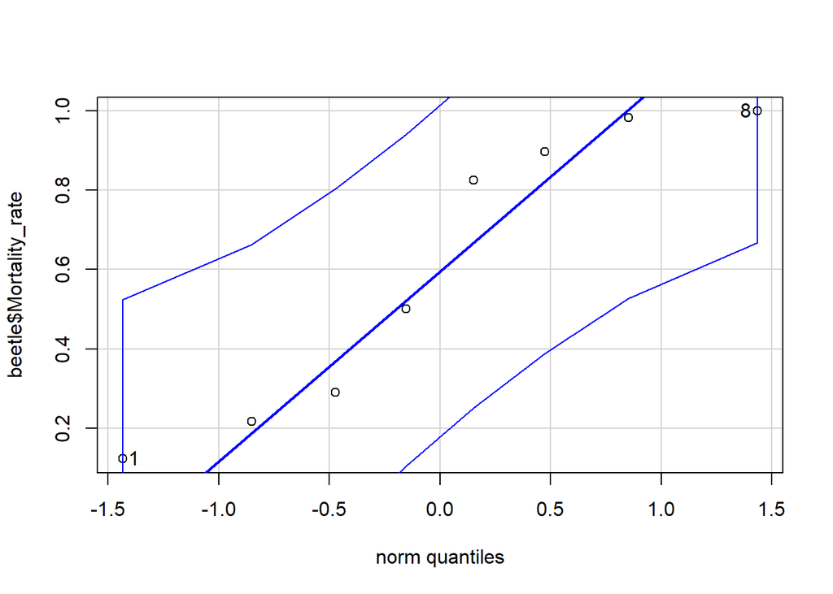

```
## [1] 1 8
```

```r
qqPlot(beetle$Mortality_rate)
```

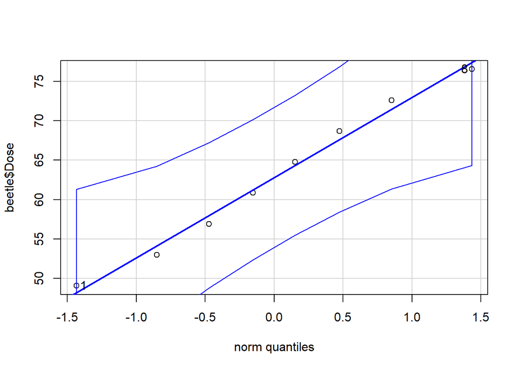

```
## [1] 1 8
```

```r
qqPlot(beetle$Dose)
```

```r
shapiro.test(beetle$Mortality_rate)
```

```
##
##  Shapiro-Wilk normality test
##
## data:  beetle$Mortality_rate
## W = 0.87002, p-value = 0.1508
```

```r
shapiro.test(beetle$Dose)
```

```
##
##  Shapiro-Wilk normality test
##
## data:  beetle$Dose
## W = 0.9749, p-value = 0.9334
```

What is the beetles probability of survival across doses of the insecticide (i.e. different concentrations of carbon disulphide in milligrams per liter).

Your answer should include an initial data visualization step, a description of your reasoning for analysis, the analysis and diagnostics as needed, a final figure, and brief conclusion statement about what the data show.

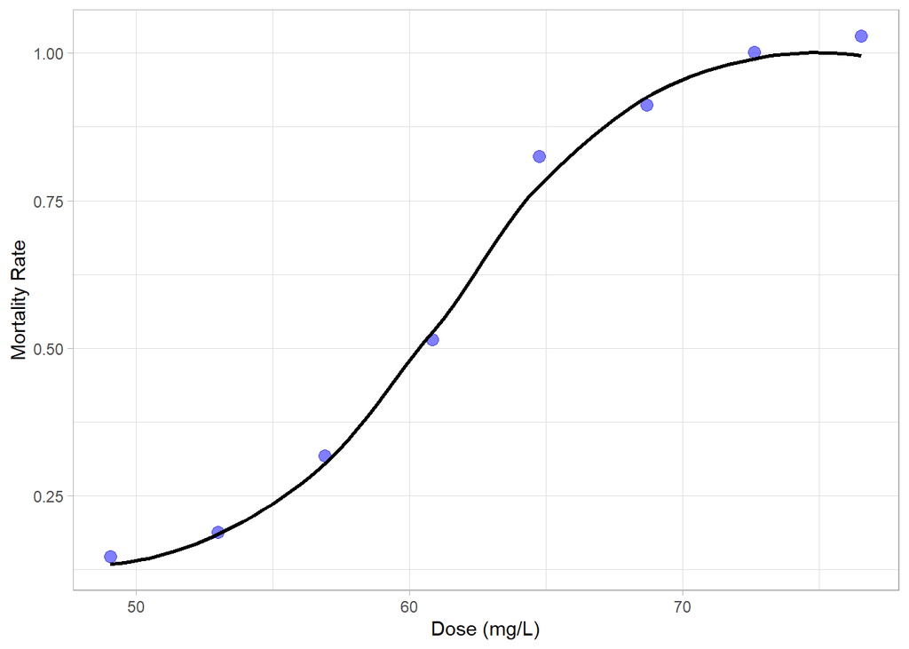

```r
library(ggplot2)
ggplot(beetle, aes(Dose, Mortality_rate)) +
  geom_jitter(color = "blue", size = 3, height = 0.04, width = 0, alpha = 0.5) + labs(x = "Dose (mg/L)", y = "Mortality Rate") + theme_light()+geom_smooth(method = "loess", size = 1, col = "black", se = FALSE) + labs(x = "Dose (mg/L)", y = "Mortality Rate") +  theme_light()
```

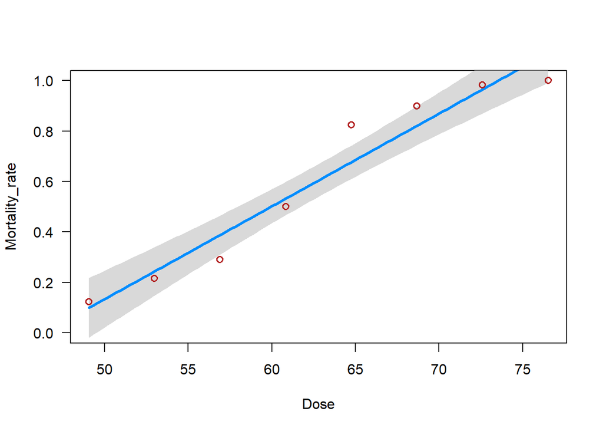

```r
blarg2 <- glm(Mortality_rate ~ Dose, family = gaussian(link="identity"), data = beetle)

library(visreg)
visreg(blarg2, xvar = "Dose", scale = 'response', rug = FALSE, ylim = c(0, 1)); points(jitter(Mortality_rate, 0.1) ~ Dose, data = beetle, pch = 1, col = "firebrick", lwd = 1.5)
```

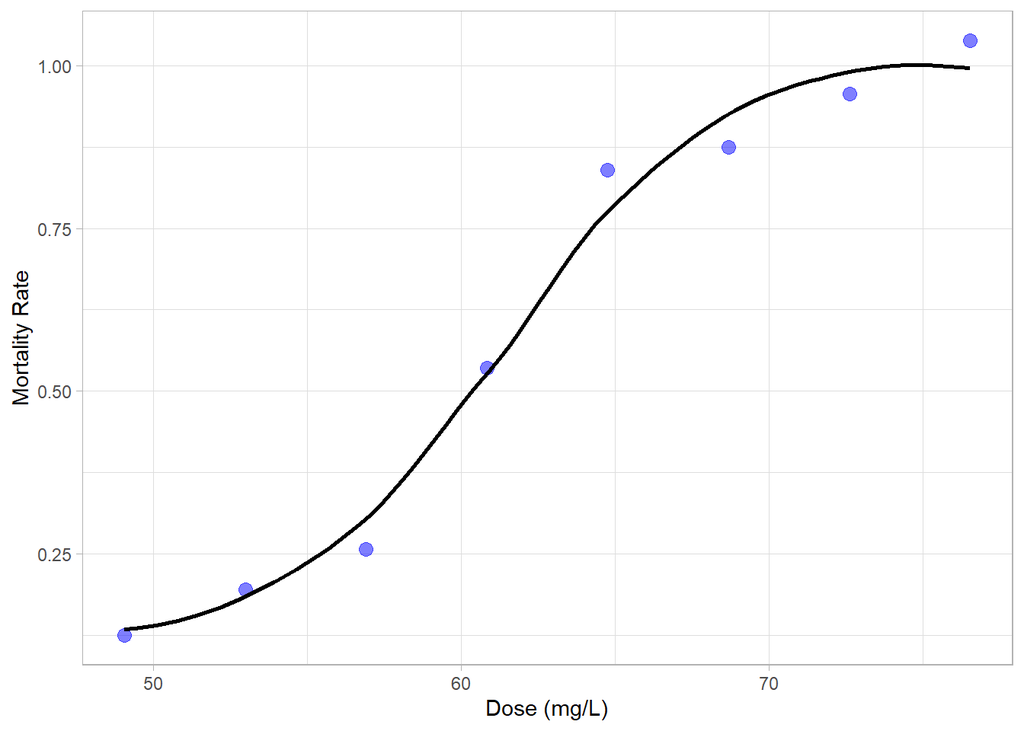

```r
ggplot(beetle, aes(Dose, Mortality_rate)) +
  geom_jitter(color = "blue", size = 3, height = 0.04, width = 0, alpha = 0.5) + labs(x = "Dose (mg/L)", y = "Mortality Rate") + theme_light()+geom_smooth(method = "loess", size = 1, col = "black", se = FALSE) + labs(x = "Dose (mg/L)", y = "Mortality Rate") +  theme_light()
```

```r
summary(blarg2)
```

```
##
## Call:
## glm(formula = Mortality_rate ~ Dose, family = gaussian(link = "identity"),
##     data = beetle)
##
## Deviance Residuals:
##       Min         1Q     Median         3Q        Max
## -0.110020  -0.048813  -0.004358   0.036670   0.148676
##
## Coefficients:
##              Estimate Std. Error t value Pr(>|t|)
## (Intercept) -1.705326   0.232950  -7.321 0.000332 ***
## Dose         0.036783   0.003672  10.017 5.74e-05 ***
## ---
## Signif. codes:  0 '***' 0.001 '**' 0.01 '*' 0.05 '.' 0.1 ' ' 1
##
## (Dispersion parameter for gaussian family taken to be 0.008725099)
##
##     Null deviance: 0.927875  on 7  degrees of freedom
## Residual deviance: 0.052351  on 6  degrees of freedom
## AIC: -11.531
##
## Number of Fisher Scoring iterations: 2
```

```r
predict(blarg2, newdata = data.frame(Dose = 60.84), type = "response")
```

```
##         1
## 0.5325323
```

```r
confint(blarg2)
```

```
##                   2.5 %      97.5 %
## (Intercept) -2.16190000 -1.24875247
## Dose         0.02958583  0.04397954
```

```r
library(car)
anova(blarg2)
```

|  | Df | Deviance | Resid. Df | Resid. Dev |
| --- | --- | --- | --- | --- |
| NULL | NA | NA | 7 | 0.9278749 |
| Dose | 1 | 0.8755243 | 6 | 0.0523506 |

```r
Anova(blarg2)
```

|  | LR Chisq | Df | Pr(>Chisq) |
| --- | --- | --- | --- |
| Dose | 100.3455 | 1 | 1.280035e-23 |

```r
summary(blarg2)
```

```
##
## Call:
## glm(formula = Mortality_rate ~ Dose, family = gaussian(link = "identity"),
##     data = beetle)
##
## Deviance Residuals:
##       Min         1Q     Median         3Q        Max
## -0.110020  -0.048813  -0.004358   0.036670   0.148676
##
## Coefficients:
##              Estimate Std. Error t value Pr(>|t|)
## (Intercept) -1.705326   0.232950  -7.321 0.000332 ***
## Dose         0.036783   0.003672  10.017 5.74e-05 ***
## ---
## Signif. codes:  0 '***' 0.001 '**' 0.01 '*' 0.05 '.' 0.1 ' ' 1
##
## (Dispersion parameter for gaussian family taken to be 0.008725099)
##
##     Null deviance: 0.927875  on 7  degrees of freedom
## Residual deviance: 0.052351  on 6  degrees of freedom
## AIC: -11.531
##
## Number of Fisher Scoring iterations: 2
```

```r
#This data set looks at continuous variables (beetle mortality rate and dose of carbon disulphide). The data has a normal distribution and passes the Shapiro-Wilk test for normality (p>.05) and also shows a normal distribution in the QQ-plots. Since we are comparing two normal continuous variables, a Gaussian linear regression was chosen as the model. The link function used for Gaussian models is "identity". The p-values for both the intercept(1st group dose) and the given groups (remaining doses) is <.05, suggesting that there is a significant difference. The null hypothesis is rejected, the alternative (correlation/strong relationship between survival and dosage) is accepted. Residual deviance is low, meaning that the predicted values of the model are close to the actual values.
```

**Problem 2 - Plant Diversity experiment**

**Background and Question** The “plant diversity data.csv”file contains data for counts of the number of species of plants counted in experimental grassland plots. In grassland systems fertilization often increases productivity of plants, but also leads to a loss of plant species diversity. One hypothesis about why this occurs is that because fertilization leads to enhanced growth (higher productivity) that it creates asymmetric competition for light (taller plants shade out shorter ones) which reduces diversity. This experiment tests this hypothesis by adding supplemental light to the understory (shaded) plants.

**The Experimental Design** The design is a fully crossed design of two factors: 1) fertilization treatment (F) + or - and 2) addition of light (L) + or -.

**Specific Question**

Determine whether there is a loss of species with fertilization and the effects of light supplementation.

```r
plants<-read.csv("~/GitHub/Plant diversity data.csv",stringsAsFactors=FALSE)
head(plants)
```

|  | Fertilizer | Light | Diversity |
| --- | --- | --- | --- |
| 1 | F- | L- | 6 |
| 2 | F- | L- | 7 |
| 3 | F- | L- | 10 |
| 4 | F- | L- | 9 |
| 5 | F- | L- | 5 |
| 6 | F- | L- | 9 |

```r
plants2 <- plants
fert <- plants2$Fertilizer
fert2 = replicate(32,0)
for (i in 1:32) {
  thisVal = fert[i]
  if (thisVal =="F-") {
    fert2[i] = 0
  }
  else{
    fert2[i] = 1
  }
}
plants2$Fertilizer <- fert2

light = plants2$Light
light2 = replicate(32,0)
for (i in 1:32) {
  thisVal = light[i]
  if (thisVal =="L-") {
    light2[i] = 0
  }
  else{
    light2[i] = 1
  }
}
plants2$Light <- light2
```

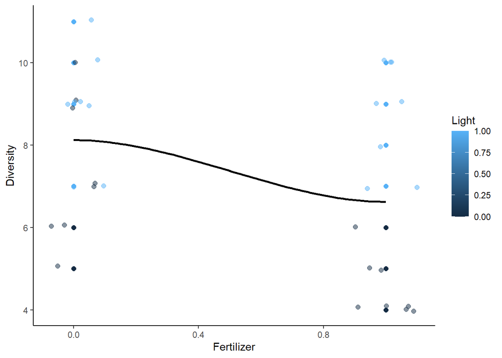

```r
library(ggplot2)

ggplot(plants2, aes(x = Fertilizer, y = Diversity, colour = Light)) +
    geom_point(size = 2) +
    labs(x = "Fertilizer", y = "Diversity") +
    theme_classic()+geom_jitter(size=2,height=.1,width=0.1,alpha=0.5)+
geom_smooth(method = "loess", size = 1, col = "black", se = FALSE) + labs(x = "Fertilizer", y = "Diversity") +  theme_classic()
```

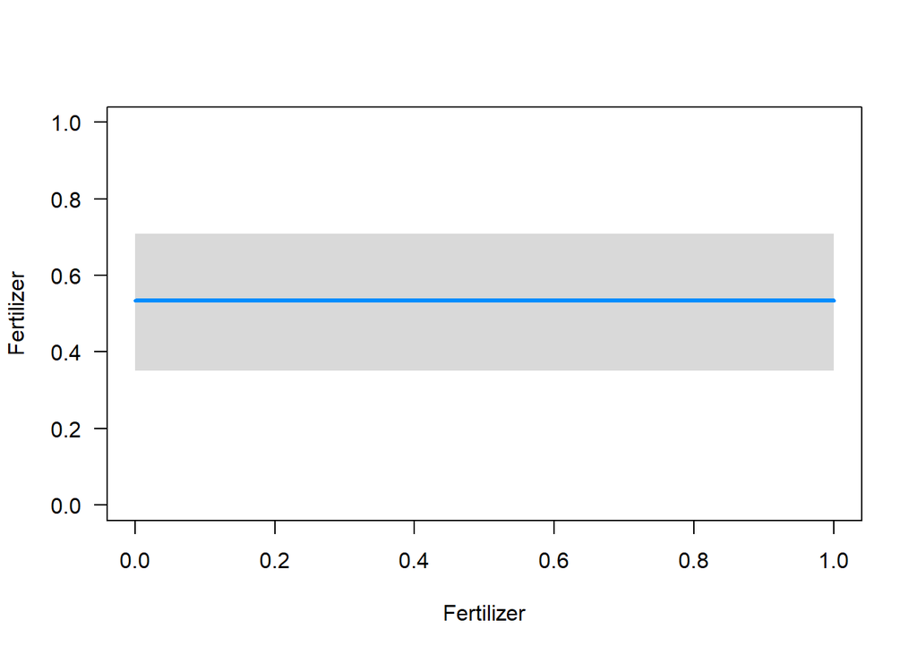

```r
dog <- glm(Fertilizer ~ Diversity, family = binomial(link="logit"),data=plants2)


library(visreg)

visreg(dog, xvar = "Fertilizer", scale = 'response', rug = FALSE, ylim = c(0, 1)); points(jitter(Diversity, 0.1) ~ Fertilizer, data = plants2, pch = 1, col = "seagreen2", lwd = 1.5)
```

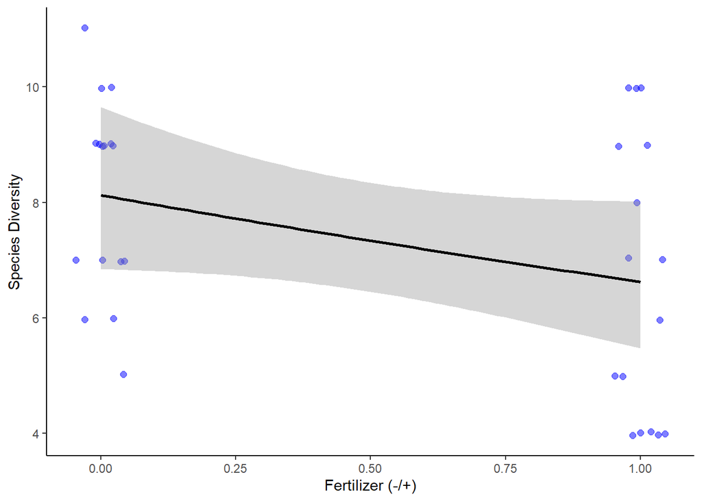

```r
ggplot(plants2, aes(x=Fertilizer, y=Diversity, colour=Light)) + geom_jitter(color = "blue", size = 2, height = 0.04, width = 0.05, alpha = 0.5) +
geom_smooth(method = "glm", method.args=list(family="poisson"), size = 1, col = "black", se = TRUE) + labs(x = "Fertilizer (-/+)", y = "Species Diversity") +  theme_classic()
```